# Capstone_Final_Report

## Context

The price of newly made cars are mostly determined by the Original General Manufacturer. However at resale the price needs to be re-determined and at that time the price is uncertain expecially based on the number of factors surrounding the vehicle.

## The Objective

The objective of this report and study is to identify and create a model that will accurately identify the appropriate price point

## Key Questions

- what are good metrics to measure our success?
- what are the most significant variables to correspond to the price?
- what need to be done to the data set before applying the model?
- what will make a good model and how will we implement it?

### Import Libraries

```python
# Import required libraries
import pandas as pd
import numpy as np

import matplotlib.pyplot as plt
import seaborn as sns

# To ignore warnings
import warnings
warnings.filterwarnings('ignore')

# Remove the limit from the number of displayed columns and rows. It helps to see the entire dataframe while printing it
pd.set_option("display.max_columns", None)

# going to be using the knn method to generate the rest of the missing values
from sklearn.impute import KNNImputer
```

### Load Data

```python
data = pd.read_csv("used_cars.csv")
```

### Preliminary Veiwing

```python
# View first 5 rows
data.head()
```

|  | S.No. | Name | Location | Year | Kilometers_Driven | Fuel_Type | Transmission | Owner_Type | Mileage | Engine | Power | Seats | New_price | Price |
| --- | --- | --- | --- | --- | --- | --- | --- | --- | --- | --- | --- | --- | --- | --- |
| 0 | 0 | Maruti Wagon R LXI CNG | Mumbai | 2010 | 72000 | CNG | Manual | First | 26.60 | 998.0 | 58.16 | 5.0 | NaN | 1.75 |
| 1 | 1 | Hyundai Creta 1.6 CRDi SX Option | Pune | 2015 | 41000 | Diesel | Manual | First | 19.67 | 1582.0 | 126.20 | 5.0 | NaN | 12.50 |
| 2 | 2 | Honda Jazz V | Chennai | 2011 | 46000 | Petrol | Manual | First | 18.20 | 1199.0 | 88.70 | 5.0 | 8.61 | 4.50 |
| 3 | 3 | Maruti Ertiga VDI | Chennai | 2012 | 87000 | Diesel | Manual | First | 20.77 | 1248.0 | 88.76 | 7.0 | NaN | 6.00 |
| 4 | 4 | Audi A4 New 2.0 TDI Multitronic | Coimbatore | 2013 | 40670 | Diesel | Automatic | Second | 15.20 | 1968.0 | 140.80 | 5.0 | NaN | 17.74 |

```python
# View last 5 rows Hint: Use tail() method
data.tail()
```

|  | S.No. | Name | Location | Year | Kilometers_Driven | Fuel_Type | Transmission | Owner_Type | Mileage | Engine | Power | Seats | New_price | Price |
| --- | --- | --- | --- | --- | --- | --- | --- | --- | --- | --- | --- | --- | --- | --- |
| 7248 | 7248 | Volkswagen Vento Diesel Trendline | Hyderabad | 2011 | 89411 | Diesel | Manual | First | 20.54 | 1598.0 | 103.6 | 5.0 | NaN | NaN |
| 7249 | 7249 | Volkswagen Polo GT TSI | Mumbai | 2015 | 59000 | Petrol | Automatic | First | 17.21 | 1197.0 | 103.6 | 5.0 | NaN | NaN |
| 7250 | 7250 | Nissan Micra Diesel XV | Kolkata | 2012 | 28000 | Diesel | Manual | First | 23.08 | 1461.0 | 63.1 | 5.0 | NaN | NaN |
| 7251 | 7251 | Volkswagen Polo GT TSI | Pune | 2013 | 52262 | Petrol | Automatic | Third | 17.20 | 1197.0 | 103.6 | 5.0 | NaN | NaN |
| 7252 | 7252 | Mercedes-Benz E-Class 2009-2013 E 220 CDI Avan... | Kochi | 2014 | 72443 | Diesel | Automatic | First | 10.00 | 2148.0 | 170.0 | 5.0 | NaN | NaN |

### Data Types and Null Values

```python
# Check the datatypes of each column. Hint: Use info() method
data.info()
```

```
<class 'pandas.core.frame.DataFrame'>
RangeIndex: 7253 entries, 0 to 7252
Data columns (total 14 columns):
 #   Column             Non-Null Count  Dtype
---  ------             --------------  -----
 0   S.No.              7253 non-null   int64
 1   Name               7253 non-null   object
 2   Location           7253 non-null   object
 3   Year               7253 non-null   int64
 4   Kilometers_Driven  7253 non-null   int64
 5   Fuel_Type          7253 non-null   object
 6   Transmission       7253 non-null   object
 7   Owner_Type         7253 non-null   object
 8   Mileage            7251 non-null   float64
 9   Engine             7207 non-null   float64
 10  Power              7078 non-null   float64
 11  Seats              7200 non-null   float64
 12  New_price          1006 non-null   float64
 13  Price              6019 non-null   float64
dtypes: float64(6), int64(3), object(5)
memory usage: 793.4+ KB
```

```python
# Check total number of missing values of each column. Hint: Use isnull() method
data.isnull().sum()
```

```
S.No.                   0
Name                    0
Location                0
Year                    0
Kilometers_Driven       0
Fuel_Type               0
Transmission            0
Owner_Type              0
Mileage                 2
Engine                 46
Power                 175
Seats                  53
New_price            6247
Price                1234
dtype: int64
```

Observations and Insights: We observe that there are a number of missing values from Engine Power and Seats. The Columns missing alot of their values are Price and New_price, where a significant portion or a majority of the entries are missing

```python
# Remove S.No. column from data. Hint: Use inplace = True
data.drop(columns=['S.No.'], inplace=True)
```

### Data Exploration

```python
# Explore basic summary statistics of numeric variables. Hint: Use describe() method.
data.describe()
```

|  | Year | Kilometers_Driven | Mileage | Engine | Power | Seats | New_price | Price |
| --- | --- | --- | --- | --- | --- | --- | --- | --- |
| count | 7253.000000 | 7.253000e+03 | 7251.000000 | 7207.000000 | 7078.000000 | 7200.000000 | 1006.000000 | 6019.000000 |
| mean | 2013.365366 | 5.869906e+04 | 18.141580 | 1616.573470 | 112.765214 | 5.280417 | 22.779692 | 9.479468 |
| std | 3.254421 | 8.442772e+04 | 4.562197 | 595.285137 | 53.493553 | 0.809277 | 27.759344 | 11.187917 |
| min | 1996.000000 | 1.710000e+02 | 0.000000 | 72.000000 | 34.200000 | 2.000000 | 3.910000 | 0.440000 |
| 25% | 2011.000000 | 3.400000e+04 | 15.170000 | 1198.000000 | 75.000000 | 5.000000 | 7.885000 | 3.500000 |
| 50% | 2014.000000 | 5.341600e+04 | 18.160000 | 1493.000000 | 94.000000 | 5.000000 | 11.570000 | 5.640000 |
| 75% | 2016.000000 | 7.300000e+04 | 21.100000 | 1968.000000 | 138.100000 | 5.000000 | 26.042500 | 9.950000 |
| max | 2019.000000 | 6.500000e+06 | 33.540000 | 5998.000000 | 616.000000 | 10.000000 | 375.000000 | 160.000000 |

## Data Exploration (Categorical variables)

```python
# Explore basic summary statistics of categorical variables. Hint: Use the argument include = ['object']
data.select_dtypes(include = ['object'])
```

|  | Name | Location | Fuel_Type | Transmission | Owner_Type |
| --- | --- | --- | --- | --- | --- |
| 0 | Maruti Wagon R LXI CNG | Mumbai | CNG | Manual | First |
| 1 | Hyundai Creta 1.6 CRDi SX Option | Pune | Diesel | Manual | First |
| 2 | Honda Jazz V | Chennai | Petrol | Manual | First |
| 3 | Maruti Ertiga VDI | Chennai | Diesel | Manual | First |
| 4 | Audi A4 New 2.0 TDI Multitronic | Coimbatore | Diesel | Automatic | Second |
| ... | ... | ... | ... | ... | ... |
| 7248 | Volkswagen Vento Diesel Trendline | Hyderabad | Diesel | Manual | First |
| 7249 | Volkswagen Polo GT TSI | Mumbai | Petrol | Automatic | First |
| 7250 | Nissan Micra Diesel XV | Kolkata | Diesel | Manual | First |
| 7251 | Volkswagen Polo GT TSI | Pune | Petrol | Automatic | Third |
| 7252 | Mercedes-Benz E-Class 2009-2013 E 220 CDI Avan... | Kochi | Diesel | Automatic | First |

7253 rows × 5 columns

```python
cat_cols = data.select_dtypes(include = ['object']).columns

for column in cat_cols:

    print("For column:", column)

    print(data[column].nunique())

    print('-'*50)
```

```
For column: Name
2041
--------------------------------------------------
For column: Location
11
--------------------------------------------------
For column: Fuel_Type
5
--------------------------------------------------
For column: Transmission
2
--------------------------------------------------
For column: Owner_Type
4
--------------------------------------------------
```

Observations and insights: The cars have teh most variance the rest of the variables are only missing a couple of variables

### Checking extreme Kilometer Values

```python
# Sort the dataset in 'descending' order using the feature 'Kilometers_Driven'
data.sort_values(by='Kilometers_Driven',ascending=False).head(10)
```

|  | Name | Location | Year | Kilometers_Driven | Fuel_Type | Transmission | Owner_Type | Mileage | Engine | Power | Seats | New_price | Price |
| --- | --- | --- | --- | --- | --- | --- | --- | --- | --- | --- | --- | --- | --- |
| 2328 | BMW X5 xDrive 30d M Sport | Chennai | 2017 | 6500000 | Diesel | Automatic | First | 15.97 | 2993.0 | 258.00 | 5.0 | NaN | 65.00 |
| 340 | Skoda Octavia Ambition Plus 2.0 TDI AT | Kolkata | 2013 | 775000 | Diesel | Automatic | First | 19.30 | 1968.0 | 141.00 | 5.0 | NaN | 7.50 |
| 1860 | Volkswagen Vento Diesel Highline | Chennai | 2013 | 720000 | Diesel | Manual | First | 20.54 | 1598.0 | 103.60 | 5.0 | NaN | 5.90 |
| 358 | Hyundai i10 Magna 1.2 | Chennai | 2009 | 620000 | Petrol | Manual | First | 20.36 | 1197.0 | 78.90 | 5.0 | NaN | 2.70 |
| 2823 | Volkswagen Jetta 2013-2015 2.0L TDI Highline AT | Chennai | 2015 | 480000 | Diesel | Automatic | First | 16.96 | 1968.0 | 138.03 | 5.0 | NaN | 13.00 |
| 3092 | Honda City i VTEC SV | Kolkata | 2015 | 480000 | Petrol | Manual | First | 17.40 | 1497.0 | 117.30 | 5.0 | NaN | 5.00 |
| 4491 | Hyundai i20 Magna Optional 1.2 | Bangalore | 2013 | 445000 | Petrol | Manual | First | 18.50 | 1197.0 | 82.90 | 5.0 | NaN | 4.45 |
| 6921 | Maruti Swift Dzire Tour LDI | Jaipur | 2012 | 350000 | Diesel | Manual | First | 23.40 | 1248.0 | 74.00 | 5.0 | NaN | NaN |
| 3649 | Tata Indigo LS | Jaipur | 2008 | 300000 | Diesel | Manual | First | 17.00 | 1405.0 | 70.00 | 5.0 | NaN | 1.00 |
| 1528 | Toyota Innova 2.5 G (Diesel) 8 Seater BS IV | Hyderabad | 2005 | 299322 | Diesel | Manual | First | 12.80 | 2494.0 | 102.00 | 8.0 | NaN | 4.00 |

#### **Observations and Insights: Based on the information of the highest kilometers driven that most vehicules are an older model and have a manual Transmission. All of the cars were first owned and have a generally consistent Mileage of around 18. Finally the all cars have 5 seating or more.**

In the first row, a car manufactured as recently as 2017 having been driven 6500000 km is almost impossible. It can be considered as data entry error and so we can remove this value/entry from data.

```python
# Removing the 'row' at index 2328 from the data. Hint: use the argument inplace=True
data.drop(index=2328, inplace=True)
```

**Check Mileage extreme values**

```python
# Sort the dataset in 'ascending' order using the feature 'Mileage'
data.sort_values(by='Mileage', ascending=True).head(10) # I believe this was suppose to be a sort_values
```

|  | Name | Location | Year | Kilometers_Driven | Fuel_Type | Transmission | Owner_Type | Mileage | Engine | Power | Seats | New_price | Price |
| --- | --- | --- | --- | --- | --- | --- | --- | --- | --- | --- | --- | --- | --- |
| 2597 | Hyundai Santro Xing XP | Pune | 2007 | 70000 | Petrol | Manual | First | 0.0 | 1086.0 | NaN | 5.0 | NaN | 1.12 |
| 2343 | Hyundai Santro AT | Hyderabad | 2006 | 74483 | Petrol | Automatic | First | 0.0 | 999.0 | NaN | 5.0 | NaN | 2.30 |
| 5270 | Honda City 1.5 GXI | Bangalore | 2002 | 53000 | Petrol | Manual | Second | 0.0 | NaN | NaN | NaN | NaN | 1.85 |
| 424 | Volkswagen Jetta 2007-2011 1.9 L TDI | Hyderabad | 2010 | 42021 | Diesel | Manual | First | 0.0 | 1968.0 | NaN | 5.0 | NaN | 5.45 |
| 6857 | Land Rover Freelander 2 TD4 SE | Mumbai | 2011 | 87000 | Diesel | Automatic | First | 0.0 | 2179.0 | 115.0 | 5.0 | NaN | NaN |
| 443 | Hyundai Santro GLS I - Euro I | Coimbatore | 2012 | 50243 | Petrol | Manual | First | 0.0 | 1086.0 | NaN | 5.0 | NaN | 3.35 |
| 5119 | Hyundai Santro Xing XP | Kolkata | 2008 | 45500 | Petrol | Manual | Second | 0.0 | 1086.0 | NaN | 5.0 | NaN | 1.17 |
| 5022 | Land Rover Freelander 2 TD4 SE | Hyderabad | 2013 | 46000 | Diesel | Automatic | Second | 0.0 | 2179.0 | 115.0 | 5.0 | NaN | 26.00 |
| 5016 | Land Rover Freelander 2 TD4 HSE | Delhi | 2013 | 72000 | Diesel | Automatic | First | 0.0 | 2179.0 | 115.0 | 5.0 | NaN | 15.50 |
| 2542 | Hyundai Santro GLS II - Euro II | Bangalore | 2011 | 65000 | Petrol | Manual | Second | 0.0 | NaN | NaN | NaN | NaN | 3.15 |

#### **Observations**

- Mileage of cars can not be 0, so we should treat 0's as missing values. We will do it in the Feature Engineering part.

## **Univariate Analysis**

Univariate analysis is used to explore each variable in a data set, separately. It looks at the range of values, as well as the central tendency of the values. It can be done for both numerical and categorical variables.

## **1. Univariate Analysis - Numerical Data**

Histograms and box plots help to visualize and describe numerical data. We use box plot and histogram to analyse the numerical columns.

```python
# Let us write a function that will help us create a boxplot and histogram for any input numerical variable.
# This function takes the numerical column as the input and returns the boxplots and histograms for the variable.

def histogram_boxplot(feature, figsize = (15, 10), bins = None):

    """ Boxplot and histogram combined

    feature: 1-d feature array

    figsize: size of fig (default (9, 8))

    bins: number of bins (default None / auto)

    """
    f2, (ax_box2, ax_hist2) = plt.subplots(nrows = 2, # Number of rows of the subplot grid = 2
                                           sharex = True, # X-axis will be shared among all subplots
                                           gridspec_kw = {"height_ratios": (.25, .75)},
                                           figsize = figsize
                                           ) # Creating the 2 subplots

    sns.boxplot(feature, ax = ax_box2, showmeans = True, color = 'violet') # Boxplot will be created and a symbol will indicate the mean value of the column

    sns.distplot(feature, kde = F, ax = ax_hist2, bins = bins, palette = "winter") if bins else sns.distplot(feature, kde = False, ax = ax_hist2) # For histogram

    ax_hist2.axvline(np.mean(feature), color = 'green', linestyle = '--') # Add mean to the histogram

    ax_hist2.axvline(np.median(feature), color = 'black', linestyle = '-') # Add median to the histogram
```

**Let us plot histogram and box-plot for the feature 'Kilometers_Driven' to understand the distribution and outliers, if any.**

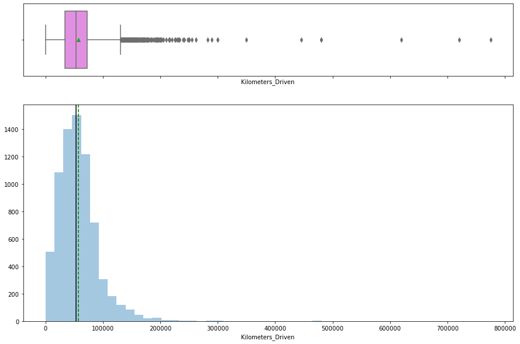

```python
# Plot histogram and box-plot for 'Kilometers_Driven'
histogram_boxplot(data['Kilometers_Driven'])
```

**Think About It**: Kilometers_Driven is highly right-skewed. Can we use Log transformation of the feature to reduce/remove the skewness? Why can't we keep skewed data? **Answer** : If we allow this skew in the data it may also skew our results

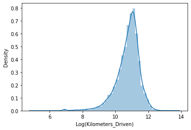

```python
# Log transformation of the feature 'Kilometers_Driven'
sns.distplot(np.log(data["Kilometers_Driven"]), axlabel = "Log(Kilometers_Driven)");
```

**Observations and Insights: The kilometers_Driven is more normalized once a log function has been applied to it**

```python
# We can add a transformed kilometers_driven feature in data
data["kilometers_driven_log"] = np.log(data["Kilometers_Driven"])
```

**Note:** Like Kilometers_Driven, the distribution of Price is also highly skewed, we can use log transformation on this column to see if that helps normalize the distribution. And add the transformed variable into the dataset. You can name the variable as **'price_log'**.

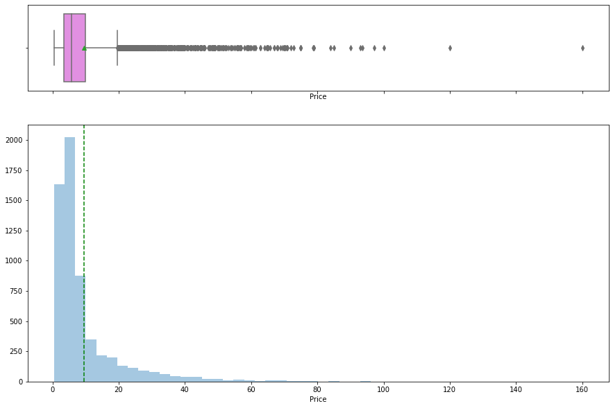

```python
# Plot histogram and box-plot for 'Price'
histogram_boxplot(data['Price'])
```

```python
# Log transformation of the feature 'Price'
price_log = np.log(data["Price"])
```

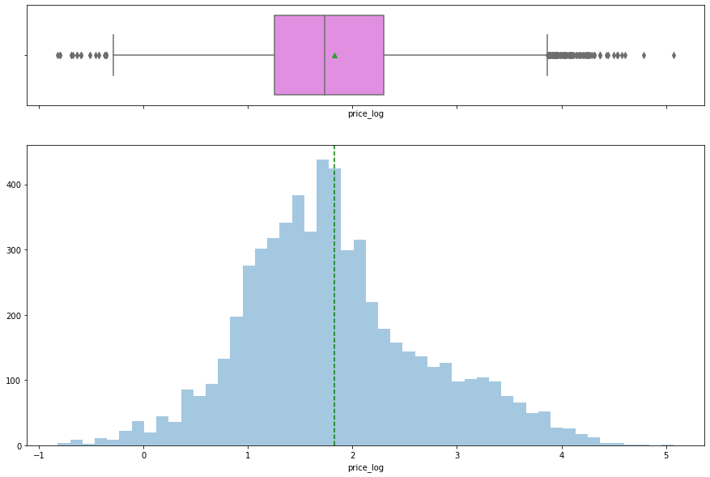

```python
# We can Add a transformed Price feature in data
data["price_log"] = price_log
histogram_boxplot(data['price_log'])
```

**Note:** Try plotting histogram and box-plot for different numerical features and understand how the data looks like.

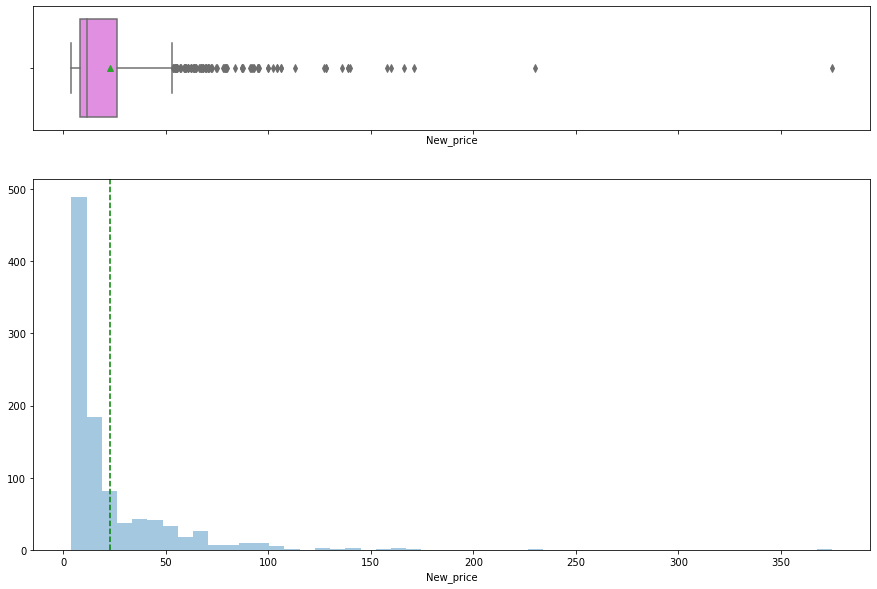

```python
histogram_boxplot(data['New_price'])
```

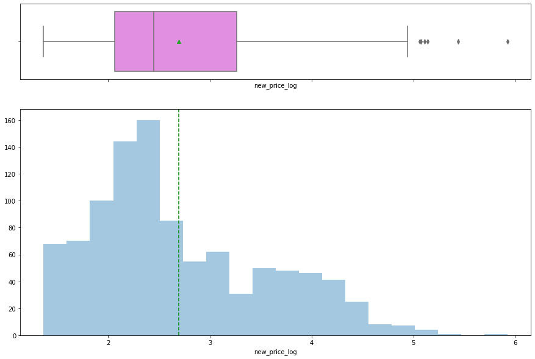

```python
data["new_price_log"] = np.log(data["New_price"])
histogram_boxplot(data['new_price_log'])
```

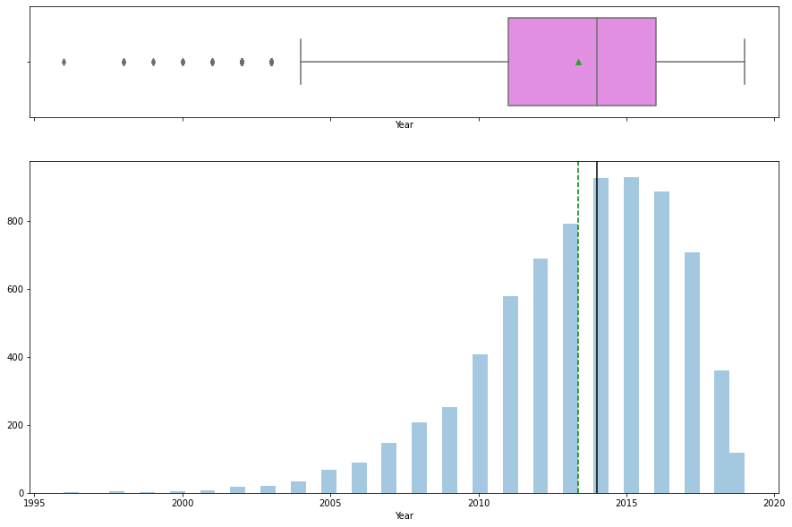

```python
histogram_boxplot(data['Year'])
```

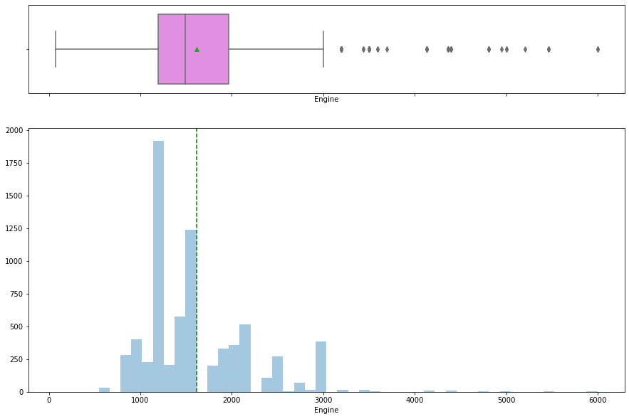

```python
histogram_boxplot(data['Engine'])
```

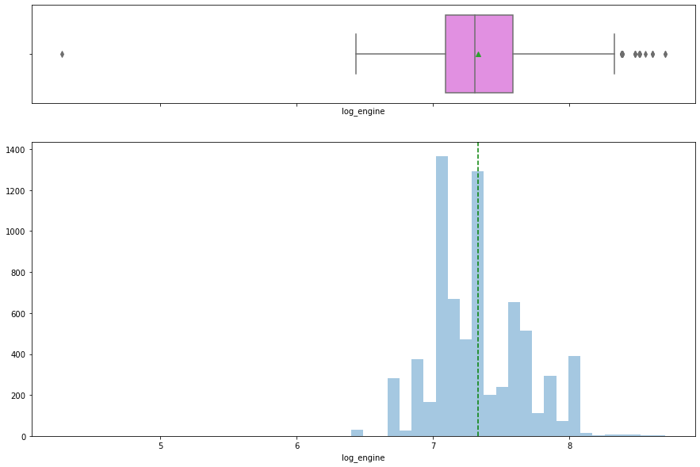

```python
data["log_engine"] = np.log(data["Engine"])
histogram_boxplot(data['log_engine'])
```

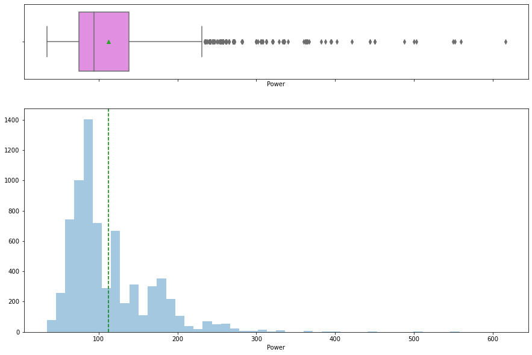

```python
histogram_boxplot(data['Power'])
```

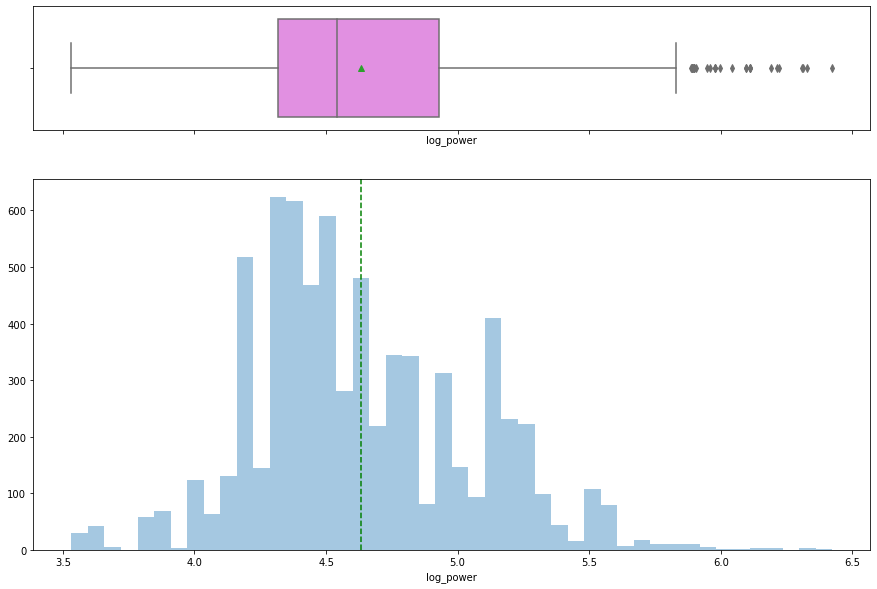

```python
data["log_power"] = np.log(data["Power"])
histogram_boxplot(data['log_power'])
```

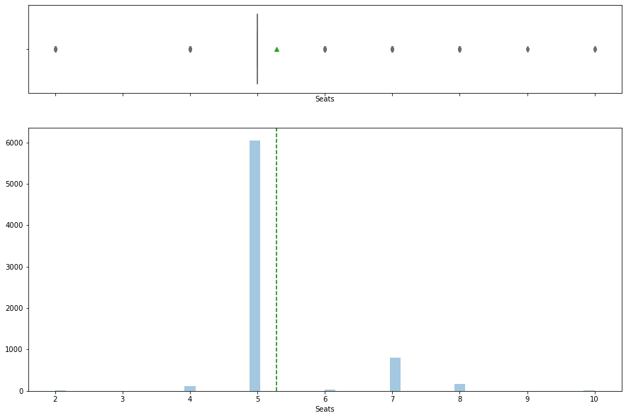

```python
histogram_boxplot(data['Seats'])
```

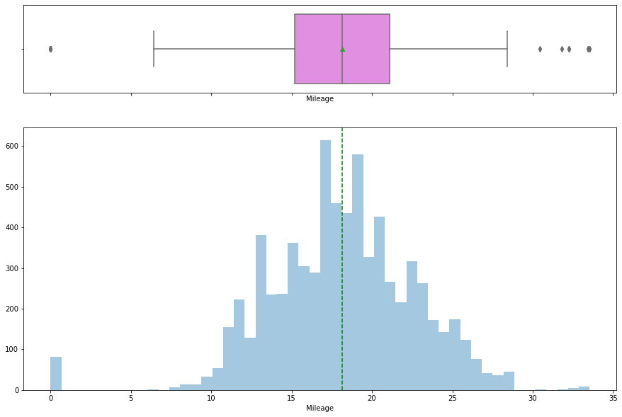

```python
histogram_boxplot(data['Mileage'])
```

**Observations and Insights for all the plots: The prices and new prices of the vehicules are very skewed and them the log function was applied to normalize them. The rest of the columns seem to fit within the normal graph parameters well enough**

As part of the box plots we see that generally when we take the log we reduce the number of outliers shown in the boxplot inplying that there the boxplot has more coverage over the points.

## **2. Univariate analysis - Categorical Data**

```python
# Let us write a function that will help us create barplots that indicate the percentage for each category.
# This function takes the categorical column as the input and returns the barplots for the variable.

def perc_on_bar(z):
    '''
    plot
    feature: categorical feature
    the function won't work if a column is passed in hue parameter
    '''

    total = len(data[z]) # Length of the column

    plt.figure(figsize = (15, 5))

    ax = sns.countplot(data[z], palette = 'Paired', order = data[z].value_counts().index)

    for p in ax.patches:

        percentage = '{:.1f}%'.format(100 * p.get_height() / total) # Percentage of each class of the category

        x = p.get_x() + p.get_width() / 2 - 0.05 # Width of the plot

        y = p.get_y() + p.get_height()           # Hieght of the plot

        ax.annotate(percentage, (x, y),size = 12) # Annotate the percantage

    # needed to add rotation to the xticks to clearly see the bar names for the brand (column that I though would add to the analysis)
    plt.xticks(rotation = 45)
    plt.show() # Show the plot
```

**Let us plot barplot for the variable location. It will be helpful to know the number of percentage of cars from each city.**

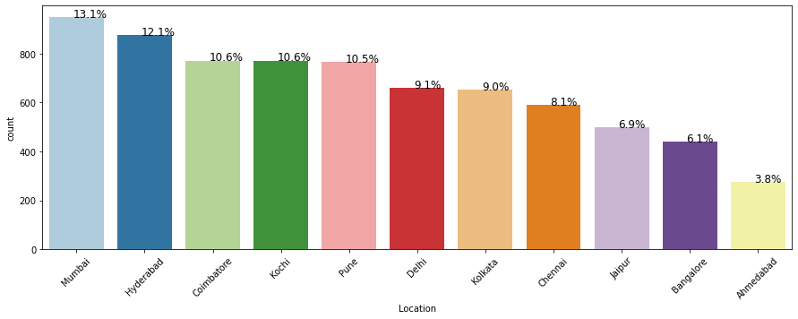

```python
# Bar Plot for 'Location'
perc_on_bar('Location')
```

**Note:** Explore for other variables like Year, Fuel_Type, Transmission, Owner_Type`.

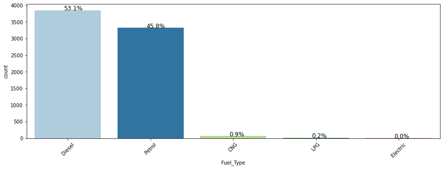

```python
perc_on_bar("Fuel_Type")
```

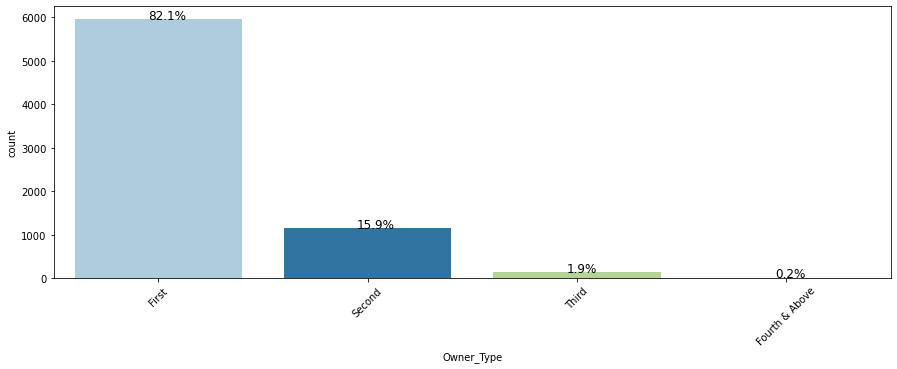

```python
perc_on_bar("Owner_Type")
```

**Observations and Insights from all plots: Overall it appears that the categorical data usually trneds to 1 or 2 types of answers. However these are values that we will not be able to normalize due to the fact these bar graph are about their percentages and not part of the values themselves.**

We will have to keep in mind that the owners skew heavily first when taking into consideration when depending on Owners vairable. Fuel type heavily skew towards Petrol and Diesel and a judgement can probably be made between the 2 of these option however it mostly disregards the rest of the fuel types. The location seems the most balanced where a decision regarding the pricing could be mostly fair.

## **Bivariate Analysis**

### **1. Scatter plot**

A scatter plot allows us to see relationships between two variables.

**Note: Use log transformed values 'kilometers_driven_log' and 'price_log'**

```python
data.info()
```

```
<class 'pandas.core.frame.DataFrame'>
Int64Index: 7252 entries, 0 to 7252
Data columns (total 18 columns):
 #   Column                 Non-Null Count  Dtype
---  ------                 --------------  -----
 0   Name                   7252 non-null   object
 1   Location               7252 non-null   object
 2   Year                   7252 non-null   int64
 3   Kilometers_Driven      7252 non-null   int64
 4   Fuel_Type              7252 non-null   object
 5   Transmission           7252 non-null   object
 6   Owner_Type             7252 non-null   object
 7   Mileage                7250 non-null   float64
 8   Engine                 7206 non-null   float64
 9   Power                  7077 non-null   float64
 10  Seats                  7199 non-null   float64
 11  New_price              1006 non-null   float64
 12  Price                  6018 non-null   float64
 13  kilometers_driven_log  7252 non-null   float64
 14  price_log              6018 non-null   float64
 15  new_price_log          1006 non-null   float64
 16  log_engine             7206 non-null   float64
 17  log_power              7077 non-null   float64
dtypes: float64(11), int64(2), object(5)
memory usage: 1.1+ MB
```

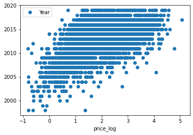

```python
# Let us plot pair plot for the variables 'year' and 'price_log'
data.plot(x = 'price_log', y = 'Year', style = 'o')
```

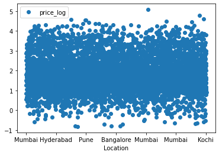

```python
data.plot(x = 'Location', y = 'price_log', style = 'o')
```

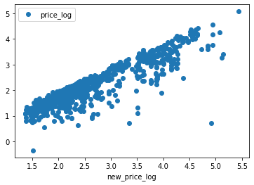

```python
data.plot(x = 'new_price_log', y = 'price_log', style = 'o')
```

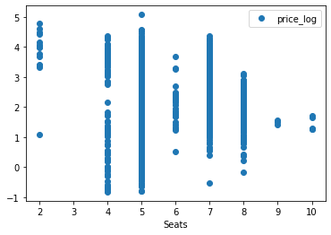

```python
data.plot(x = 'Seats', y = 'price_log', style = 'o')
```

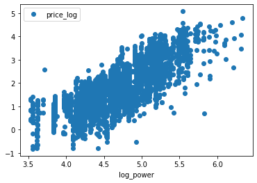

```python
data.plot(x = 'log_power', y = 'price_log', style = 'o')
```

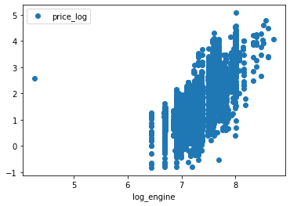

```python
data.plot(x = 'log_engine', y = 'price_log', style = 'o')
```

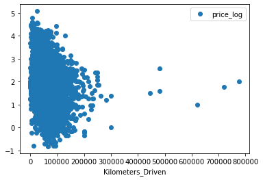

```python
data.plot(x = 'Kilometers_Driven', y = 'price_log', style = 'o')
```

**Note:** Try to explore different combinations of independent variables and dependent variable. Understand the relationship between all variables.

**Observations and Insights from all plots:**

- Generally we see large clusters due to the outliers. If there aren't any outliers we can determine that some variables such as location doesn't appear to have an impact on the price while vairables such as new_price_log, log_engine, and log_power have a correlation with the price.

### **2. Heat map**

Heat map shows a 2D correlation matrix between two numerical features.

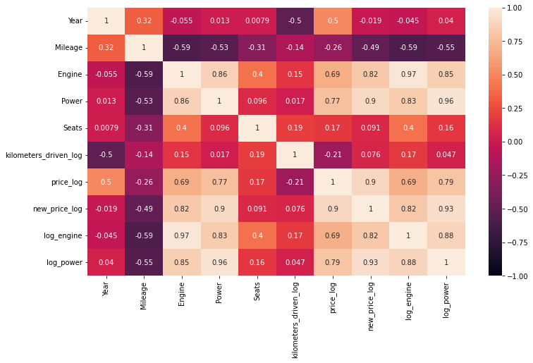

```python
# We can include the log transformation values and drop the original skewed data columns
plt.figure(figsize = (12, 7))

sns.heatmap(data.drop(["Kilometers_Driven","Price", "New_price"],axis = 1).corr(), annot = True, vmin = -1, vmax = 1)

plt.show()
```

**Observations and Insights:** Focusing on the 2 parameters that interest us the Price_log and the new_price_log. There is a signigifcant correlation between the 2 price columns as well as the Engine, and Power. Something to note is that the price appears to also depend on the Year of the car, whereas for the new price the year appears to matter very little.

### **3. Box plot**

```python
# Let us write a function that will help us create boxplot w.r.t Price for any input categorical variable.
# This function takes the categorical column as the input and returns the boxplots for the variable.
def boxplot(z):

    plt.figure(figsize = (12, 5)) # Setting size of boxplot

    sns.boxplot(x = z, y = data['Price']) # Defining x and y
    plt.xticks(rotation=90)
    plt.show()

    plt.figure(figsize = (12, 5))

    plt.title('Without Outliers')

    sns.boxplot(x = z, y = data['Price'], showfliers = False) # Turning off the outliers
    plt.xticks(rotation=90)

    plt.show()
```